# Homework 10

Anna Schmidt

3/30/2022

**1. Using a `for` loop, write a function to calculate the number of zeroes in a numeric vector. Before entering the loop, set up a counter variable `counter <- 0`. Inside the loop, add 1 to `counter` each time you have a zero in the vector. Finally, use `return(counter)` for the output.**

```r
################################
# FUNCTION: calculate_zeroes
# purpose: calculate the number of zeroes in a numeric vector
# input: vec = numeric vector
# output: counter = number of zeroes in the numeric vector
# ------------------------------

calculate_zeroes <- function(vec = c(0, 0, 5, 1)) {
  counter <- 0 # set up counter variable
  for (i in 1:length(vec)) {
    if (vec[i] == 0) counter <- counter + 1
    } # end of for loop
  return(counter) # output
} # end of function

calculate_zeroes() # test defaults, counter should = 2
```

```
## [1] 2
```

```r
calculate_zeroes(c(0, 10, 25, 0, 0, 0)) # test a different vector, counter should = 4
```

```
## [1] 4
```

**2. Use subsetting instead of a loop to rewrite the function as a single line of code.**

```r
vec <- c(0, 0, 5, 1)

length(which(vec == 0)) # should = 2
```

```
## [1] 2
```

**3. Write a function that takes as input two integers representing the number of rows and columns in a matrix. The output is a matrix of these dimensions in which each element is the product of the row number x the column number.**

```r
################################
# FUNCTION: matrix_products
# purpose: create a matrix in which each element is the product of its row# x column#
# input: nrow = integer representing the number of rows in a matrix
#        ncol = integer representing the number of columns in a matrix
# output: m = matrix of dimension(nrow,ncol)
# ------------------------------

matrix_products <- function(nrow = 3,
                            ncol = 4) {
  m <- matrix(runif(nrow*ncol), nrow = nrow) # create matrix with random values

  # double for loop to loop over rows and columns
  for (i in 1:nrow(m)) { # loop over rows
    for (j in 1:ncol(m)) { # loop over columns
      m[i,j] <- i*j
      } # end of column loop
    } # end of row loop

  return(m)

} # end of function

matrix_products() # test defaults
```

```
##      [,1] [,2] [,3] [,4]
## [1,]    1    2    3    4
## [2,]    2    4    6    8
## [3,]    3    6    9   12
```

```r
matrix_products(nrow = 5, ncol = 6) # test with different inputs
```

```
##      [,1] [,2] [,3] [,4] [,5] [,6]
## [1,]    1    2    3    4    5    6
## [2,]    2    4    6    8   10   12
## [3,]    3    6    9   12   15   18
## [4,]    4    8   12   16   20   24
## [5,]    5   10   15   20   25   30
```

**4. In the next few lectures, you will learn how to do a randomization test on your data. We will complete some of the steps today to practice calling custom functions within a for loop. Use the code from the March 31st lecture (Randomization Tests) to complete the following steps:**

**a. Simulate a dataset with 3 groups of data, each group drawn from a distribution with a different mean. The final data frame should have 1 column for group and 1 column for the response variable.**

```r
library(tidyverse)
# Create random numbers for three groups of data
control <- rnorm(n = 10, mean = 10, sd = 10)     # mean = 10
treatmentA <- rnorm(n = 10, mean = 60, sd = 10)  # mean = 60
treatmentB <- rnorm(n = 10, mean = 85, sd = 10)  # mean = 85

# Create data frame
d_frame <- data.frame(control, treatmentA, treatmentB)

# Make the data frame longer
d_frame <- d_frame %>%
  pivot_longer(cols = control:treatmentB,
               names_to = "group",
               values_to = "response_var")
head(d_frame)
```

```
## # A tibble: 6 × 2
##   group      response_var
##   <chr>             <dbl>
## 1 control           -2.43
## 2 treatmentA        62.4
## 3 treatmentB        75.3
## 4 control            4.55
## 5 treatmentA        66.1
## 6 treatmentB        78.9
```

**b. Write a custom function that 1) reshuffles the response variable, and 2) calculates the mean of each group in the reshuffled data. Store the means in a vector of length 3.**

```r
################################
# FUNCTION: randomization_test
# purpose: reshuffle the response variable and calculate the mean of each group in the reshuffled data
# input: df = data frame with "response_var" and "group" columns
# output: means = vector of length 3, containing the means of each group
# ------------------------------

randomization_test <- function(df = NULL) {
  if(is.null(df)) {
    df <- data.frame(group = rep(c("control", "treatmentA", "treatmentB"), each = 10),
                     response_var = runif(30, min = 0, max = 200))
  }

  # reshuffle the response variable
  df$response_var <- sample(df$response_var)

  # calculate the mean of each group in the reshuffled data, and store the means in a vector of length 3
  means <- tapply(df$response_var, df$group, mean)
  return(means)

} # end of function

randomization_test() # test defaults
```

```
##    control treatmentA treatmentB
##  106.03594  128.36496   91.00624
```

```r
randomization_test(df = d_frame) # test with our data frame
```

```
##    control treatmentA treatmentB
##   41.72707   71.53991   45.81773
```

**c. Use a for loop to repeat the function in b 100 times. Store the results in a data frame that has 1 column indicating the replicate number and 1 column for each new group mean, for a total of 4 columns.**

```r
# Create empty data frame with all NAs
results <- data.frame(replicate = rep(NA,100),
                      means_control = rep(NA,100),
                      means_treatmentA = rep(NA,100),
                      means_treatmentB = rep(NA,100))

# For loop to repeat randomization_test() 100 times
for (i in 1:100) {
  means <- randomization_test(df = d_frame) # run randomization_test() function

  results$replicate[i] <- i # fill in replicate column

  results$means_control[i] <- means["control"] # fill in means_control column
  results$means_treatmentA[i] <- means["treatmentA"] # fill in means_treatmentA column
  results$means_treatmentB[i] <- means["treatmentB"] # fill in means_treatmentB column

} # end of for loop

head(results)
```

```
##   replicate means_control means_treatmentA means_treatmentB
## 1         1      56.38405         54.02563         48.67504
## 2         2      39.89146         61.40292         57.79032
## 3         3      46.35043         67.98075         44.75353
## 4         4      69.65125         38.28163         51.15183
## 5         5      54.14551         46.82154         58.11766
## 6         6      54.02171         40.89792         64.16508
```

**d. Use qplot() to create a histogram of the means for each reshuffled group. Or, if you want a challenge, use ggplot() to overlay all 3 histograms in the same figure. How do the distributions of reshuffled means compare to the original means?**

```r
# First, make the data frame longer
results_long <- results %>%
  pivot_longer(cols = means_control:means_treatmentB,
               names_to = "group",
               values_to = "means")

head(results_long)
```

```
## # A tibble: 6 × 3
##   replicate group            means
##       <int> <chr>            <dbl>
## 1         1 means_control     56.4
## 2         1 means_treatmentA  54.0
## 3         1 means_treatmentB  48.7
## 4         2 means_control     39.9
## 5         2 means_treatmentA  61.4
## 6         2 means_treatmentB  57.8
```

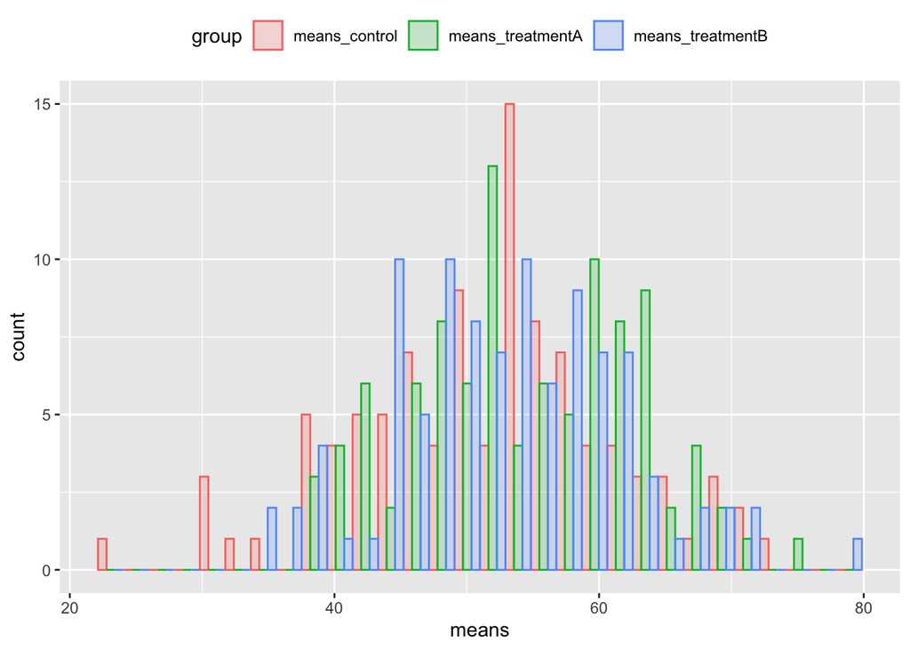

```r
# all on the same plot
ggplot(data = results_long,
       aes(x = means, fill = group, color = group)) +
  geom_histogram(position = "dodge", alpha = 0.2) +
  theme(legend.position="top")
```

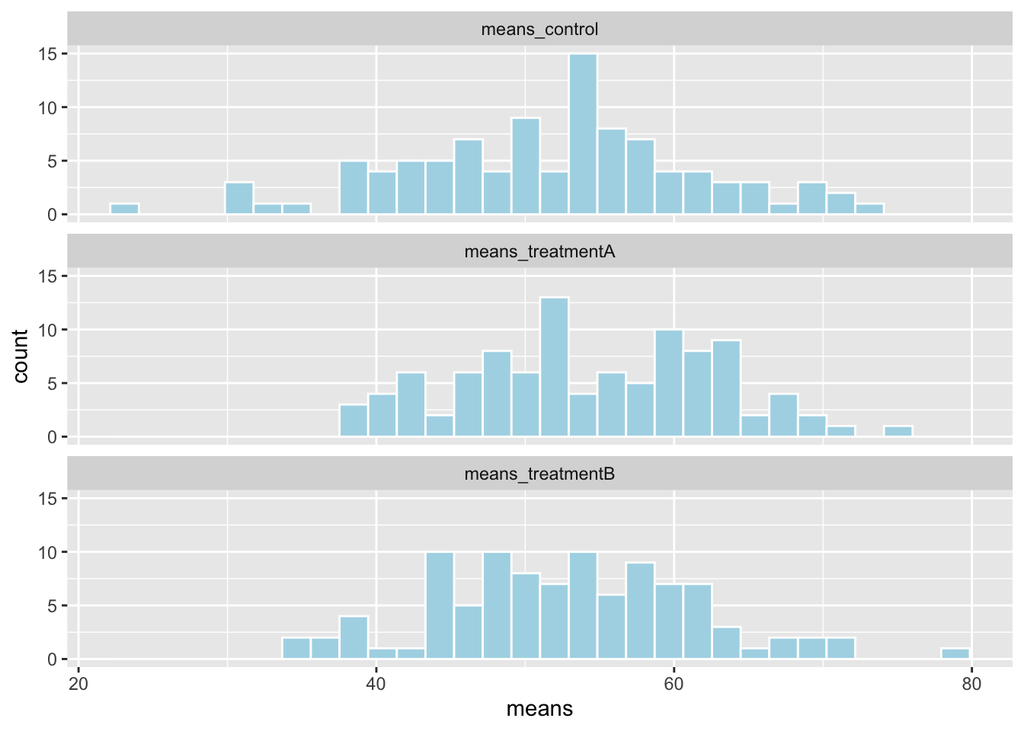

```r
# faceted
ggplot(data = results_long,
       aes(x = means)) +
  geom_histogram(fill = "lightblue", col = "white", position = "dodge") +
  theme(legend.position="top") +
  facet_wrap(~group, nrow = 3)
```

The distributions of reshuffled means for the control, treatmentA, and treatmentB groups all look relatively similar, and they are all centered around a mean of 55. It makes sense that these distributions all look similar since the response variables were randomly shuffled in the randomization_test() function. Since the original means were control = 10, treatmentA = 60, and treatmentB = 85, the fact that these distributions are centered around 55 makes sense, since that is centered in the context of the original means.

Back to Home Page